# Soc-Xsit Analysis and Vizualizations

Kyle MacDonald

January 17, 2015

Clear workspace and set working directory

Read in data from all 3 Experiments:

- Large scale experiment manipulating attention and memory demands
- Replication of Experiment 1 with more ecologically valid stimulus set
- Parametric manipulation of cue reliablity

## Experiment 1

### Get the number of subjects in each condition.

```r
nsubs <- df_expt1 %>% group_by(condition, intervalNum, numPicN) %>% summarise(n_subs = n_distinct(subids))

pandoc.table(nsubs, style = "rmarkdown")
```

```
##
##
## |  condition  |  intervalNum  |  numPicN  |  n_subs  |
## |:-----------:|:-------------:|:---------:|:--------:|
## |  No-Social  |       0       |     2     |   127    |
## |  No-Social  |       0       |     4     |   114    |
## |  No-Social  |       0       |     6     |    39    |
## |  No-Social  |       0       |     8     |   117    |
## |  No-Social  |       1       |     2     |   120    |
## |  No-Social  |       1       |     4     |   118    |
## |  No-Social  |       1       |     6     |    35    |
## |  No-Social  |       1       |     8     |   114    |
## |  No-Social  |       3       |     2     |   115    |
## |  No-Social  |       3       |     4     |   117    |
## |  No-Social  |       3       |     6     |    36    |
## |  No-Social  |       3       |     8     |   114    |
## |  No-Social  |       7       |     2     |   129    |
## |  No-Social  |       7       |     4     |   115    |
## |  No-Social  |       7       |     6     |    34    |
## |  No-Social  |       7       |     8     |   114    |
## |   Social    |       0       |     2     |    48    |
## |   Social    |       0       |     4     |    82    |
## |   Social    |       0       |     6     |    37    |
## |   Social    |       0       |     8     |    43    |
## |   Social    |       1       |     2     |    44    |
## |   Social    |       1       |     4     |    88    |
## |   Social    |       1       |     6     |    44    |
## |   Social    |       1       |     8     |    44    |
## |   Social    |       3       |     2     |    47    |
## |   Social    |       3       |     4     |    87    |
## |   Social    |       3       |     6     |    40    |
## |   Social    |       3       |     8     |    43    |
## |   Social    |       7       |     2     |    47    |
## |   Social    |       7       |     4     |    90    |
## |   Social    |       7       |     6     |    38    |
## |   Social    |       7       |     8     |    38    |
```

### Do some minor data cleaning and create variables

Flag trials on which subs chose the target of eye gaze.

```r
df_expo_expt1 <- df_expt1 %>%
    filter(exposureTrial == 1) %>%
    mutate(correct_exposure = ifelse(numPic == 6,
                                     chosenIdx == faceIdx6,
                                     chosenIdx == faceIdx)) %>%
    select(subids, itemNum, correct_exposure)
```

Get test trials and merge with exposure trial information.

```r
df_test_expt1 <- df_expt1 %>% filter(testTrial == 1)
df_test_expt1 <- join(df_expo_expt1, df_test_expt1, type = "full")
```

Flag subs in the social condition who performed worse than chance on exposure trials.

```r
df_test_expt1 <- df_test_expt1 %>%
    filter(condition == "Social") %>%
    group_by(subids, numPic) %>%
    summarise(mean_acc_exp = mean(correct_exposure)) %>%
    mutate(include_expo = ifelse(numPic == 2 & mean_acc_exp > 0.5, 1,
                                 ifelse(numPic == 4 & mean_acc_exp > 0.25, 1,
                                        ifelse(numPic == 6 & mean_acc_exp > 0.17, 1,
                                               ifelse(numPic == 8 & mean_acc_exp > 0.125, 1,
                                                      0))))) %>%
    join(df_test_expt1, by = "subids", type = "full")
```

Flag test trials with really slow or fast RTs (+/- 2SD).

```r
df_test_expt1 <- df_test_expt1 %>%
    mutate(include_good_rt = ifelse(log(rt) > mean(log(rt)) + 2 * sd(log(rt)) |
                                        log(rt) < mean(log(rt)) - 2 * sd(log(rt)),
                                    0, 1))
```

Flag exposure trials with really slow or fast RTs (+/- 2SD).

```r
df_expo_expt1_analysis <- df_expt1 %>%
    filter(exposureTrial == 1, rt > 0) %>%
    mutate(include_good_rt = ifelse(log(rt) > mean(log(rt)) + 2 * sd(log(rt)) |
                                        log(rt) < mean(log(rt)) - 2 * sd(log(rt)),
                                    0, 1)) %>%
    filter(include_good_rt == 1)
```

### Set up filters

Get test trials for analysis. Here we have 2 filters:

- Remove fast/slow RTs
- Remove fast/slow RTs & subjects who performed below chance selecting gaze target on exposure trials

```r
# just RT filter
df_test_expt1 <- df_test_expt1 %>%
    filter(include_good_rt == 1)

# subject and trial level filter
df_test_expt1_filt <- df_test_expt1 %>%
    filter(include_good_rt == 1, include_expo == 1 | condition == "No-Social") %>%
    filter(correct_exposure == T | condition == "No-Social")
```

Get the number of subjects filtered out

```r
df_n <- df_test_expt1 %>%
    group_by(condition) %>%
    summarise(n_subs = n_distinct(subids))

df_n_filt <- df_test_expt1_filt %>%
    group_by(condition) %>%
    summarise(n_subs_filt = n_distinct(subids)) %>%
    select(n_subs_filt)

df_n <- cbind(df_n, df_n_filt)

df_n
```

```
##   condition n_subs n_subs_filt
## 1 No-Social   1557        1557
## 2    Social    860         770
```

### Accuracy on exposure trials in social condition

Get means and CIs for each combination of number of referents and interval

```r
ms_expo_expt1 <-  df_test_expt1 %>%
    filter(condition == "Social") %>%
    group_by(numPic, intervalNum) %>%
    summarise(accuracy_exposure = mean(correct_exposure),
              ci_low = ci.low(correct_exposure),
              ci_high = ci.high(correct_exposure))
```

Now plot those means.

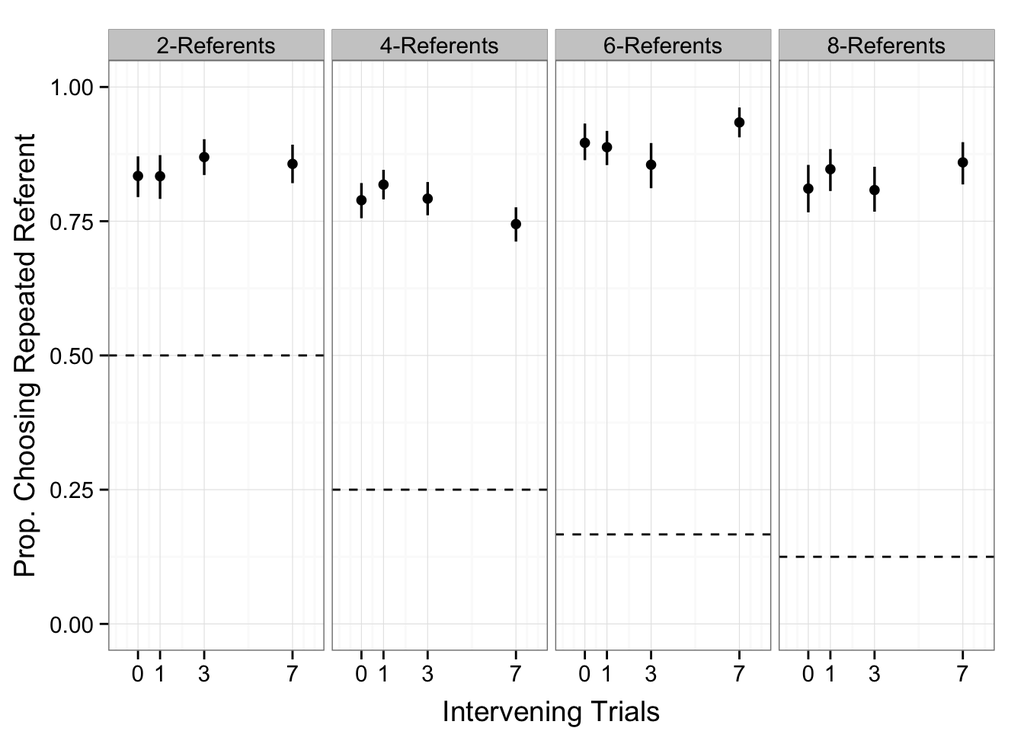

### RT on exposure trials

Next we compare reaction times across social/no-social at different levels of attention and memory demands.

```r
ms_expo_rt_expt1 <-  df_expo_expt1_analysis %>%
    group_by(numPic, intervalNum, condition) %>%
    summarise(mean_rt = mean(rt),
              ci_low = ci.low(rt),
              ci_high = ci.high(rt))
```

Now we plot mean reaction times for each condition.

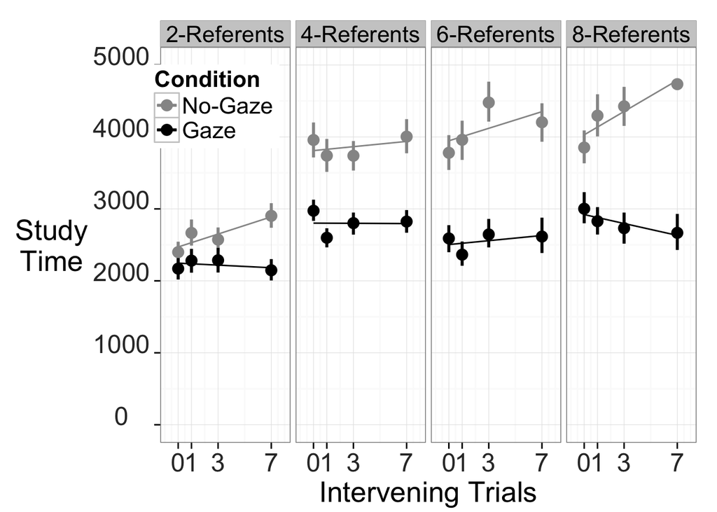

### Accuracy on test trials

First we aggregate for both unfiltered and filtered data.

```r
ms_test_expt1 <- df_test_expt1  %>%
    group_by(condition, intervalNum, numPic, trialType) %>%
    summarise(accuracy = mean(correct),
              ci_low = ci.low(correct),
              ci_high = ci.high(correct),
              exclusionary_criteria = "none")

ms_test_filt_expt1 <- df_test_expt1_filt  %>%
    group_by(condition, intervalNum, numPic, trialType) %>%
    summarise(accuracy = mean(correct),
              ci_low = ci.low(correct),
              ci_high = ci.high(correct),
              exclusionary_criteria = "Subject and Trial level")

ms_test_all_expt1 <- rbind(ms_test_expt1, ms_test_filt_expt1)
```

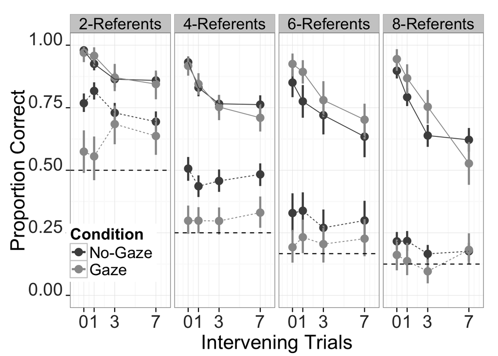

### LMERs

#### Predicting RT on exposure trials.

```r
m1_rt_expt1 <- lmer(rt ~ condition * log2(intervalNum + 1) * log2(numPicN) +
                  (1|subids), data=df_expo_expt1_analysis)
```

#### Predict accuracy on test trials.

```r
# 2-way model
m1_2way_expt1 <- glmer(correct ~ (trialType + condition +
                                      log2(intervalNum + 1) + log2(numPicN))^2 +
                           (trialType | subids),
                       data=df_test_expt1_filt, family=binomial, nAGQ=0)

# 3-way model
m1_3way_expt1 <- glmer(correct ~ (trialType + condition +
                                      log2(intervalNum + 1) + log2(numPicN))^3 +
                           (trialType | subids),
                       data=df_test_expt1_filt, family=binomial, nAGQ=0)


# 4-way model
m1_4way_expt1 <- glmer(correct ~ (trialType + condition +
                                      log2(intervalNum + 1) + log2(numPicN))^4 +
                           (trialType | subids),
                       data=df_test_expt1_filt, family=binomial, nAGQ=0)


# model comparison
model_comp <- anova( m1_2way_expt1, m1_3way_expt1, m1_4way_expt1)

pandoc.table(model_comp, style="rmarkdown")
```

```
##
##
## |       &nbsp;        |  Df  |  AIC  |  BIC  |  logLik  |  deviance  |
## |:-------------------:|:----:|:-----:|:-----:|:--------:|:----------:|
## |  **m1_2way_expt1**  |  14  | 17219 | 17328 |  -8595   |   17191    |
## |  **m1_3way_expt1**  |  18  | 17211 | 17351 |  -8588   |   17175    |
## |  **m1_4way_expt1**  |  19  | 17213 | 17361 |  -8588   |   17175    |
##
## Table: Table continues below
##
##
##
## |       &nbsp;        |  Chisq  |  Chi Df  |  Pr(>Chisq)  |
## |:-------------------:|:-------:|:--------:|:------------:|
## |  **m1_2way_expt1**  |   NA    |    NA    |      NA      |
## |  **m1_3way_expt1**  |  15.44  |    4     |   0.003878   |
## |  **m1_4way_expt1**  | 0.1762  |    1     |    0.6747    |
```

3-way model is best based on model comparison.

#### Compare the 3-way model for filtered and unfiltered data.

```r
# 2-way model unfiltered
m1_2way_expt1_unfilt <- glmer(correct ~ (trialType + condition +
                                      log2(intervalNum + 1) + log2(numPicN))^2 +
                           (trialType | subids),
                       data=df_test_expt1, family=binomial, nAGQ=0)

# 3-way model unfiltered
m1_3way_expt1_unfilt <- glmer(correct ~ (trialType + condition +
                                      log2(intervalNum + 1) + log2(numPicN))^3 +
                           (trialType | subids),
                       data=df_test_expt1, family=binomial, nAGQ=0)
```

## Experiment 2: Replication with ecologically valid stimulus set

In Experiment 2, we chose a subset of the referent/interval conditions: numPic = 4, and interval = 0 and 3.

Get the number of subjects in each condition.

```r
df_expt2 %>%
    group_by(condition, interval) %>%
    summarise(n_subs = n_distinct(subids))
```

```
## Source: local data frame [4 x 3]
## Groups: condition
##
##        condition interval n_subs
## 1 No-socialFirst    Three     90
## 2 No-socialFirst     Zero     92
## 3    SocialFirst    Three     92
## 4    SocialFirst     Zero     93
```

### Minor data cleaning, variable creation, and filters

Create variable to track experiment block.

```r
df_expt2 <- df_expt2 %>%
    mutate(block = ifelse(itemNum <= 7, "first","second"))
```

Flag trials with extremely slow or fast RTs (+/- 2SD).

```r
df_expt2 <- df_expt2 %>%
    mutate(include_good_rt = ifelse(log(rt) > mean(log(rt)) + 2 * sd(log(rt)) |
                                        log(rt) < mean(log(rt)) - 2 * sd(log(rt)),
                                    0,1))
```

### Flag social vs. no-social trials

Create a variable to track the condition for each trial.

```r
df_expt2 <- df_expt2 %>%
      mutate(condition_trial = ifelse(condition == "No-socialFirst"
                                      & itemNum <= 7, "no-social",
                                      ifelse(condition == "SocialFirst"
                                             & itemNum <= 7, "social",
                                             ifelse(condition == "No-socialFirst"
                                                    & itemNum >= 8, "social",
                                                    ifelse(condition == "SocialFirst"
                                                           & itemNum >= 8,
                                                           "no-social", NA)))))
```

### Flag subs who got <25% of exposure trials correct.

```r
ss_exposure <- df_expt2 %>%
      filter(trial_cat == "exposure" & condition_trial == "social") %>%
      group_by(subids) %>%
      summarise(mean_acc_exp = mean(correct))

# Merge mean acc with the rest of the dataset.
df_expt2 <- merge(df_expt2, ss_exposure, by = "subids")
```

### Flag test trials on which subject chose target of gaze on exposure

```r
df_expt2 <- df_expt2 %>%
    filter(trial_cat == "exposure") %>%
    mutate(correct_exposure = faceIdx == chosenIdx,
             rt_exposure = rt) %>%
    select(subids, itemNum, correct_exposure, rt_exposure) %>%
    merge(df_expt2, by = c("subids", "itemNum"))
```

### Set up filters

Exposure trials.

```r
# just RT filter
df_expo_expt2 <- filter(df_expt2,
                      include_good_rt == 1,
                      condition_trial == "social",
                      trial_cat == "exposure")

# RT, subject level and trial level filter
df_expo_expt2_filt <- filter(df_expt2,
                           trial_cat == "exposure",
                           condition_trial == "social" & mean_acc_exp > 0.25,
                           include_good_rt == 1)

# filter that gets both social/no-social trials
df_expo_expt2_analysis <- df_expt2 %>%
    filter(trial_cat == "exposure",
           mean_acc_exp > 0.25,
           correct_exposure = T | condition_trial == "no-social",
           include_good_rt == 1)
```

Get the number of subjects filtered out by the subject level filter.

```r
df_n_expt2 <- df_expo_expt2 %>%
    group_by(condition) %>%
    summarise(n_subs = n_distinct(subids))

df_n_expt2_filt <- df_expo_expt2_filt %>%
    group_by(condition) %>%
    summarise(n_subs_filt = n_distinct(subids)) %>%
    select(n_subs_filt)

nsubs_expt2 <- cbind(df_n_expt2, df_n_expt2_filt)

nsubs_expt2
```

```
##        condition n_subs n_subs_filt
## 1 No-socialFirst    181         159
## 2    SocialFirst    185         162
```

Test trial filters.

```r
# just RT filter
df_test_expt2 <- df_expt2 %>%
    filter(trial_cat == "test",
           include_good_rt == 1)

# RT, subject level and trial level filter
df_test_expt2_filt <- df_expt2 %>%
    filter(trial_cat == "test",
           mean_acc_exp > 0.25 ,
           include_good_rt == 1,
           correct_exposure == T | condition_trial == "no-social")
```

### Analyze Exposure Trials

Accuracy, selecting target of gaze.

```r
# unfiltered
ms_expo_expt2 <- df_expo_expt2 %>%
    group_by(intervalNum) %>%
    summarise(accuracy_exposure = mean(correct),
              ci_low = ci.low(correct),
              ci_high = ci.high(correct)) %>%
    mutate(filter = "Unfiltered")

# filtered
ms_expo_expt2_filt <- df_expo_expt2_filt %>%
    group_by(intervalNum) %>%
    summarise(accuracy_exposure = mean(correct),
              ci_low = ci.low(correct),
              ci_high = ci.high(correct)) %>%
    mutate(filter = "Filtered")

ms_expo_all_expt2 <- rbind(ms_expo_expt2, ms_expo_expt2_filt)
```

Now plot mean correct for exposure trials for each interval.

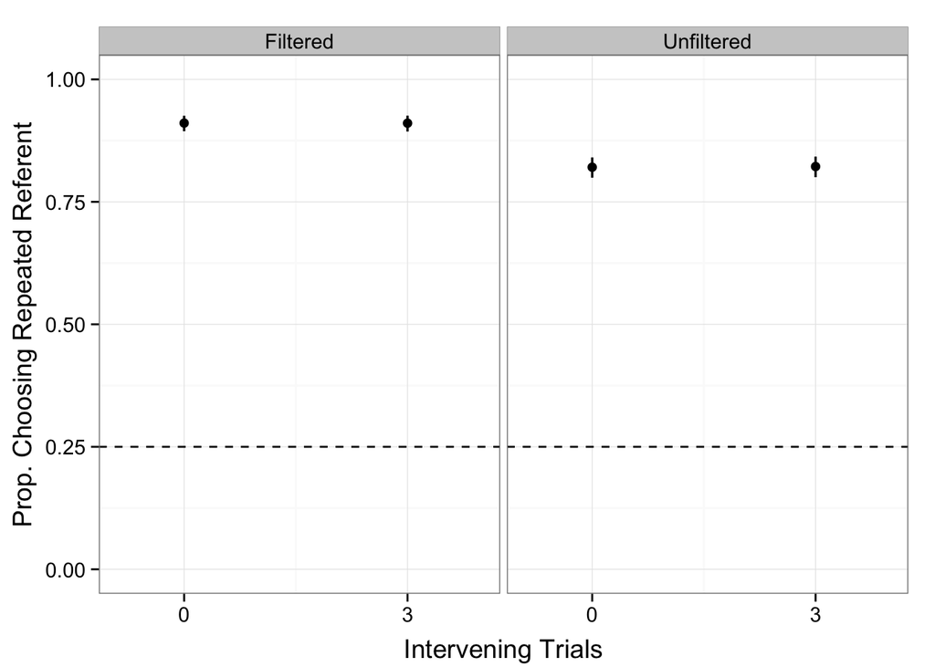

RT on exposure trials.

```r
ms_rt_expo_expt2 <- df_expo_expt2_analysis %>%
    group_by(condition_trial, intervalNum) %>%
    summarise(rt_exposure = mean(rt),
              ci_low = ci.low(rt),
              ci_high = ci.high(rt))
```

Plot RT differences

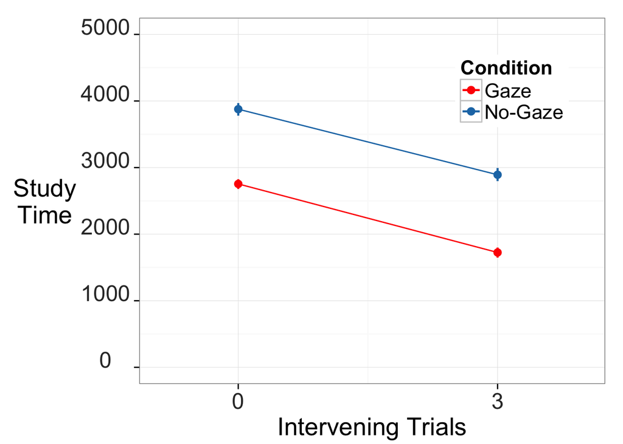

## Analyze test trials

Get means and CIs for each condition.

```r
# unfiltered
ms_test_expt2 <- df_test_expt2 %>%
    group_by(trialType, condition_trial, intervalNum) %>%
    summarise(accuracy = mean(correct),
              ci_low = ci.low(correct),
              ci_high = ci.high(correct)) %>%
    mutate(filter = "Unfiltered")

# filtered (subject level)
ms_test_expt2_filt <- df_test_expt2_filt %>%
    group_by(trialType, condition_trial, intervalNum) %>%
    summarise(accuracy = mean(correct),
              ci_low = ci.low(correct),
              ci_high = ci.high(correct)) %>%
    mutate(filter = "Filtered")

ms_test_all_expt2 <- rbind(ms_test_expt2, ms_test_expt2_filt)
```

Now plot accuracy for test trials.

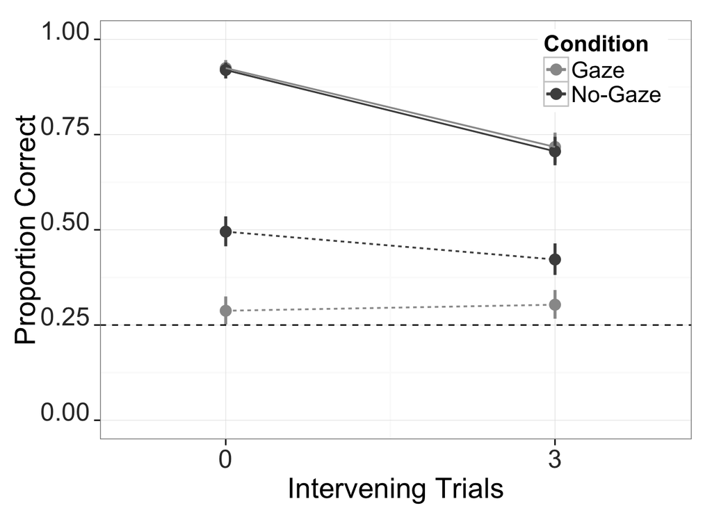

### LMERs

Predicting RT on exposure trials.

```r
m1_rt_expt2 <- lmer(rt ~ condition_trial * log2(intervalNum + 1) * log2(numPicN) +
                  (1|subids), data=df_expo_expt2_analysis)
```

```
## fixed-effect model matrix is rank deficient so dropping 4 columns / coefficients
```

Comparing models with different levels of complexity.

```r
# filtered 2-way
m1_expt2_2way_filt <- glmer(correct ~ (trialType + condition_trial + intervalNum)^2 +
                             (trialType | subids), nAGQ=0,
                         data = df_test_expt2_filt,
                         family=binomial)

# filtered 3-way
m1_expt2_3_way_filt <- glmer(correct ~ (trialType + condition_trial + intervalNum)^3 +
                             (trialType | subids), nAGQ=0,
                         data = df_test_expt2_filt,
                         family=binomial)

model_comp_expt2 <- anova(m1_expt2_2way_filt, m1_expt2_3_way_filt)

pandoc.table(model_comp_expt2, style="rmarkdown")
```

```
##
##
## |          &nbsp;           |  Df  |  AIC  |  BIC  |  logLik  |
## |:-------------------------:|:----:|:-----:|:-----:|:--------:|
## |  **m1_expt2_2way_filt**   |  10  | 4978  | 5042  |  -2479   |
## |  **m1_expt2_3_way_filt**  |  11  | 4979  | 5049  |  -2478   |
##
## Table: Table continues below
##
##
##
## |          &nbsp;           |  deviance  |  Chisq  |  Chi Df  |
## |:-------------------------:|:----------:|:-------:|:--------:|
## |  **m1_expt2_2way_filt**   |    4958    |   NA    |    NA    |
## |  **m1_expt2_3_way_filt**  |    4957    |  1.301  |    1     |
##
## Table: Table continues below
##
##
##
## |          &nbsp;           |  Pr(>Chisq)  |
## |:-------------------------:|:------------:|
## |  **m1_expt2_2way_filt**   |      NA      |
## |  **m1_expt2_3_way_filt**  |    0.254     |
```

3-way is no better than the 2-way.

### LMERs comparing filtered vs. unfiltered data.

```r
# unfilt 2-way
m1_expt2_unfilt <- glmer(correct ~ (trialType + condition_trial + intervalNum)^2 +
                             (trialType | subids), nAGQ=0,
                         data = df_test_expt2,
                         family=binomial)

# filtered 2-way
m1_expt2_filt <- glmer(correct ~ (trialType + condition_trial + intervalNum)^2 +
                             (trialType | subids), nAGQ=0,
                         data = df_test_expt2_filt,
                         family=binomial)
```

## Experiment 3: Parametric reliability manipulation

Minor data cleaning and variable creation.

```r
# create clean reliablity variable
df_expt3$prop_cond_clean <- revalue(df_expt3$condition,
                                    c("0%_reliable" = "0%",
                                      "25%_reliable" = "25%",
                                      "50%_reliable" = "50%",
                                      "75%_reliable" = "75%",
                                      "100%_reliable" = "100%"))

# change order of condition factor for plotting
df_expt3$prop_cond_clean <- factor(df_expt3$prop_cond_clean,
                                   levels = c("0%", "25%",
                                              "50%", "75%", "100%"))

# Create continuous variable for reliability
df_expt3$reliability[df_expt3$prop_cond_clean=="0%"] <- .00
df_expt3$reliability[df_expt3$prop_cond_clean=="25%"] <- .25
df_expt3$reliability[df_expt3$prop_cond_clean=="50%"] <- .50
df_expt3$reliability[df_expt3$prop_cond_clean=="75%"] <- .75
df_expt3$reliability[df_expt3$prop_cond_clean=="100%"] <- 1.00
```

### Clean up RTs.

```r
# remove trials with 0 RT
df_expt3 <- filter(df_expt3, rt > 0)

# clean RTs
df_expt3 <- df_expt3 %>%
    mutate(include_good_rt = ifelse(log(rt) > mean(log(rt)) + 2 * sd(log(rt)) |
                                        log(rt) < mean(log(rt)) - 2 * sd(log(rt)),
                                    0,1))
```

### Get the number of subjects in each experiment and condition.

```r
df_expt3 %>%
      group_by(prop_cond_clean) %>%
      summarise(n_subs = n_distinct(subids))
```

```
## Source: local data frame [5 x 2]
##
##   prop_cond_clean n_subs
## 1              0%     99
## 2             25%     97
## 3             50%    100
## 4             75%     98
## 5            100%     96
```

### Set up filters

Exposure trials:

```r
# all expsoure trials
df_expo_all_expt3 <- df_expt3 %>%
    filter(trial_category == "exposure",
           include_good_rt == 1)

# exposures trials in the familiarization block
df_expo_fam_expt3 <- df_expt3 %>%
    filter(trial_category == "exposure" &
               block == "familiarization",
           include_good_rt == 1)

# exposure trials in the test block
df_expo_test_expt3 <- df_expt3 %>%
    filter(trial_category == "exposure" &
               block == "test",
           include_good_rt == 1)
```

Test trials:

```r
# all test trials
df_test_all_expt3 <- df_expt3 %>%
    filter(trial_category == "test",
           include_good_rt == 1)

# test trials in the familiarization block
df_test_fam_expt3 <- df_expt3 %>%
    filter(trial_category == "test" &
               block == "familiarization",
           include_good_rt == 1)

# test trials in the test block
df_test_test_expt3 <- df_expt3 %>%
    filter(trial_category == "test" &
               block == "test",
           include_good_rt == 1)
```

Flag whether participant chose the target of eye gaze on exposure trials in the test block.

```r
df_correct_expo_test <- df_expo_test_expt3 %>%
    select(subids, gaze_target, chosen,
           correct_exposure = correct, itemNum)

df_test_test <- merge(df_test_test_expt3, df_correct_expo_test,
                          by=c("subids", "itemNum"))
```

### Analyze Familiarization Block

RT on exposure trials.

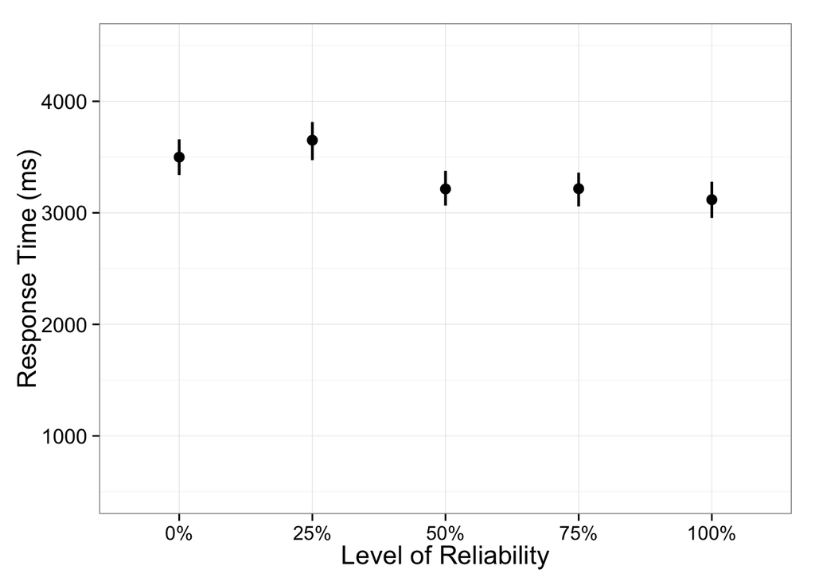

```r
ms_rt_expo_fam <- df_expo_fam_expt3 %>%
    group_by(prop_cond_clean) %>%
    summarise(rt_exposure = mean(rt),
              ci_low = ci.low(rt),
              ci_high = ci.high(rt))

ggplot(ms_rt_expo_fam,
       aes(x=prop_cond_clean, y=rt_exposure)) +
    geom_pointrange(aes(ymin=rt_exposure - ci_low,
                        ymax=rt_exposure + ci_high),
                    width = .1, size = 0.8) +
    scale_y_continuous(limits=c(500,4500)) +
    ylab("Response Time (ms)") +
    xlab("Level of Reliability") +
    theme(text = element_text(size=16),
          axis.text.x  = element_text(angle=0, vjust=0.5, size=12))
```

Accuracy on test trials in familiarization block

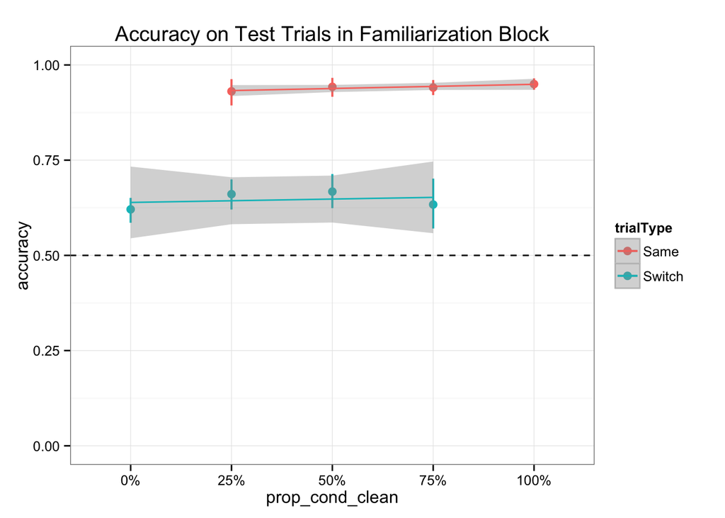

```r
ms_test_fam <- df_test_fam_expt3 %>%
      group_by(prop_cond_clean, trialType) %>%
      summarise(accuracy = mean(correct),
                ci_low = ci.low(correct),
                ci_high = ci.high(correct))

ggplot(ms_test_fam,
       aes(x=prop_cond_clean, y=accuracy,
           group=trialType, colour=trialType)) +
    geom_pointrange(aes(ymin=accuracy - ci_low,
                        ymax=accuracy + ci_high),
                    width = .1, size=0.7) +
    geom_hline(yintercept=0.5, linetype = "dashed") +
    scale_y_continuous(limits=c(0,1)) +
    geom_smooth(method='lm') +
    ggtitle("Accuracy on Test Trials in Familiarization Block")
```

Split this by first and second half.

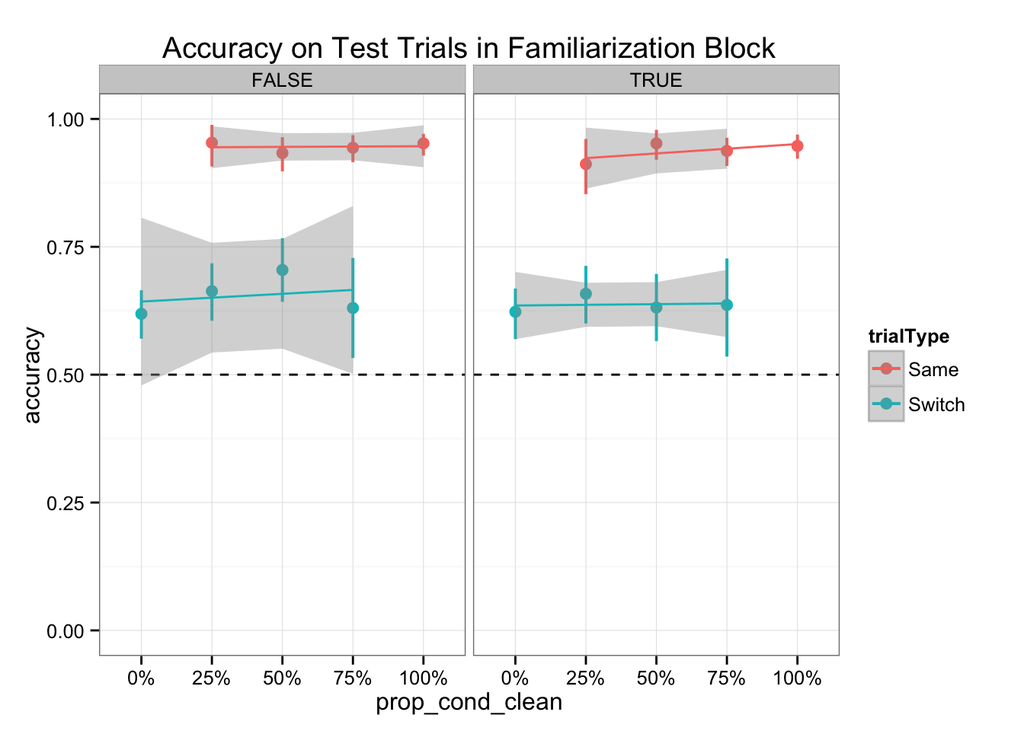

```r
ms_test_fam <- df_test_fam_expt3 %>%
    mutate(second_half = itemNum > 3) %>%
      group_by(prop_cond_clean, trialType, second_half) %>%
      summarise(accuracy = mean(correct),
                ci_low = ci.low(correct),
                ci_high = ci.high(correct))

ggplot(ms_test_fam,
       aes(x=prop_cond_clean, y=accuracy,
           group=trialType, colour=trialType)) +
    geom_pointrange(aes(ymin=accuracy - ci_low,
                        ymax=accuracy + ci_high),
                    width = .1, size=0.7) +
    geom_hline(yintercept=0.5, linetype = "dashed") +
    scale_y_continuous(limits=c(0,1)) +
    geom_smooth(method='lm') +
    facet_grid(.~second_half) +
    ggtitle("Accuracy on Test Trials in Familiarization Block")
```

#### Analyze performance on test block

Anayze RT on exposure trials in the test block.

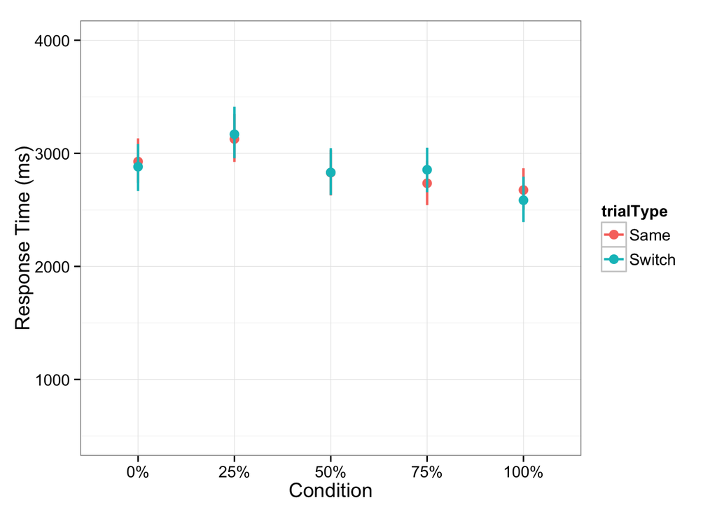

```r
ms_rt_expo_test <- df_expo_test_expt3 %>%
    group_by(prop_cond_clean, trialType) %>%
    summarise(rt_exposure = mean(rt),
              ci_low = ci.low(rt),
              ci_high = ci.high(rt))

ggplot(ms_rt_expo_test,
       aes(x=prop_cond_clean, y=rt_exposure, color = trialType)) +
    geom_pointrange(aes(ymin=rt_exposure - ci_low,
                        ymax=rt_exposure + ci_high),
                    width = .1, size = 0.8) +
    scale_y_continuous(limits=c(500,4000)) +
    ylab("Response Time (ms)") +
    xlab("Condition") +
    theme(text = element_text(size=14))
```

Accuracy on familiarization trials in test block

```r
ms_expo_test <- df_test_test %>%
      group_by(prop_cond_clean) %>%
      summarise(accuracy = mean(correct_exposure),
                ci_low = ci.low(correct_exposure),
                ci_high = ci.high(correct_exposure))
```

Now plot chose target of gaze

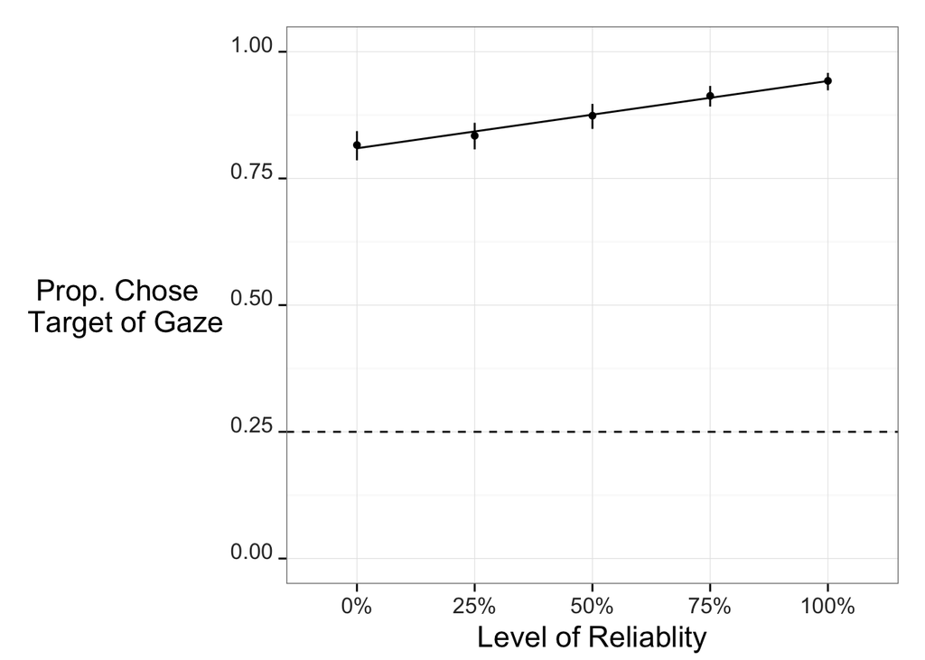

```r
expt3_chose_gazetar_plot <- ggplot(ms_expo_test,
                                   aes(x=prop_cond_clean, y=accuracy, group=1)) +
    geom_smooth(method="lm", se=F, color="black") +
    geom_pointrange(aes(ymin=accuracy - ci_low,
                        ymax=accuracy + ci_high), width=.1, size=0.5) +
    geom_hline(yintercept=0.25, linetype = "dashed") +
    scale_y_continuous(limits=c(0,1)) +
    xlab("Level of Reliablity") +
    ylab("Prop. Chose \n Target of Gaze") +
    theme(axis.title.x = element_text(colour="black",size=16,
                                      angle=0,hjust=0.5,vjust=0,face="plain"),
          axis.title.y = element_text(colour="black",size=16,
                                      angle=0,hjust=0.5,vjust=0.5,face="plain"),
          axis.text.x = element_text(colour="grey20",size=12,
                                     angle=0,hjust=0.5,vjust=0,face="plain"),
          axis.text.y = element_text(colour="grey20",size=12,
                                     angle=0,hjust=0.5,vjust=0,face="plain"),
          legend.position=c(0.85,0.85),
          legend.text = element_text(size=13),
          legend.title = element_text(size=13, face="bold"))

expt3_chose_gazetar_plot
```

```r
# save plot
ggsave("exp3-acc-exposure.pdf", expt3_chose_gazetar_plot, width=5.5, height=3.5)
```

Accuracy on test trials in the test block

```r
ms_test_test <- df_test_test %>%
      group_by(prop_cond_clean, trialType) %>%
      summarise(accuracy = mean(correct),
                ci_low = ci.low(correct),
                ci_high = ci.high(correct))
```

Now plot.

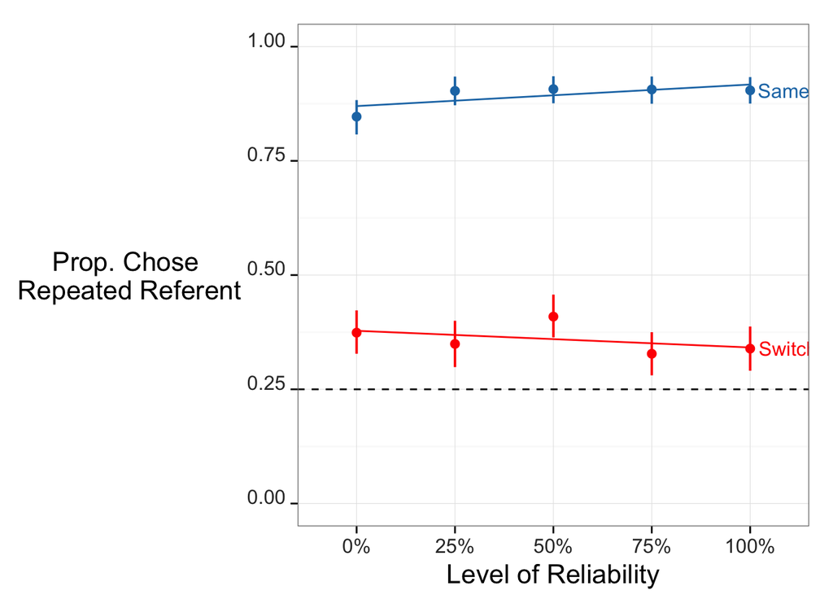

Analyze subject reported reliablity

```r
df_test_test$rel_subj <- as.numeric(as.character(df_test_test$rel_subj))
```

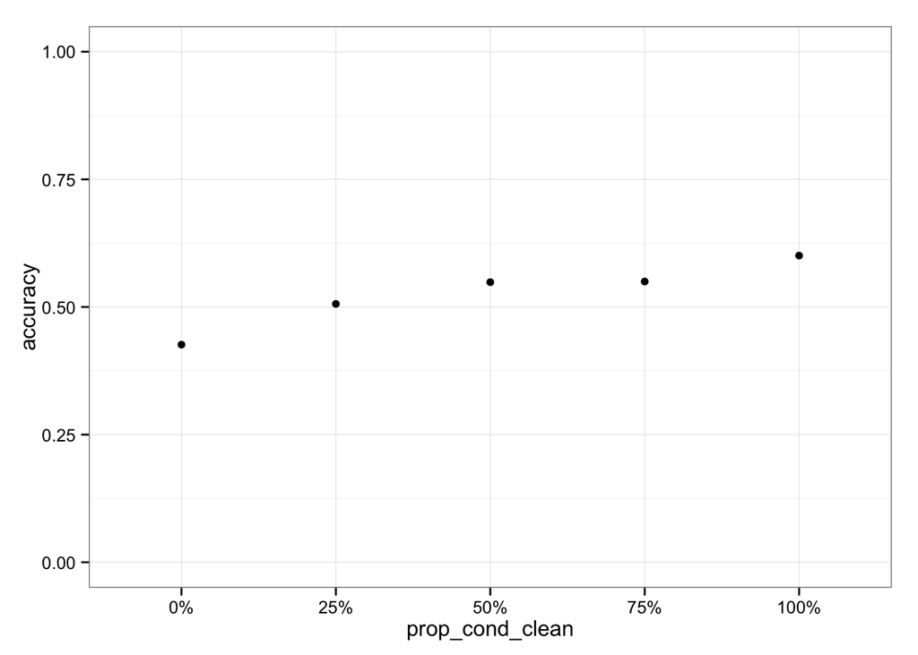

```r
ms_test_subj_rel <- df_test_test %>%
      group_by(prop_cond_clean) %>%
      summarise(accuracy = mean(rel_subj,na.rm=TRUE),
                ci_low = ci.low(rel_subj),
                ci_high = ci.high(rel_subj))

qplot(x=prop_cond_clean, y=accuracy, data=ms_test_subj_rel) +
    ylim(c(0,1))
```

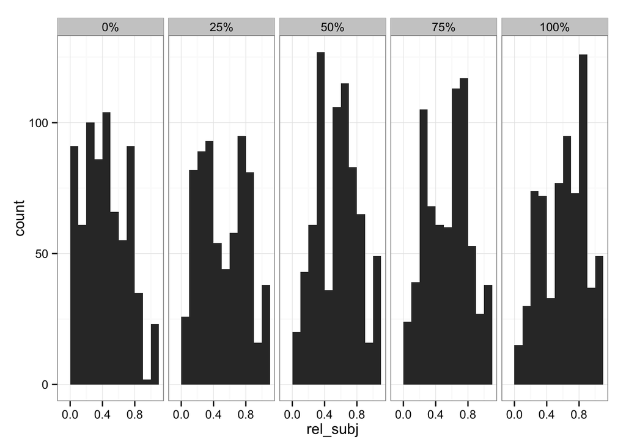

```r
qplot(rel_subj, facets=.~prop_cond_clean, data=df_test_test, binwidth=.1)
```

Reported reliability vs. number correct on exposure - individual consistency.

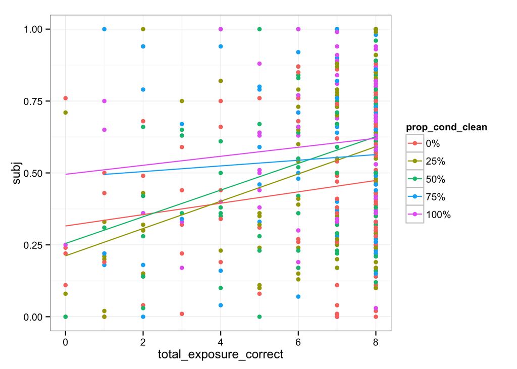

```r
df_test_test <- df_test_test %>%
    group_by(subids) %>%
    mutate(total_exposure_correct = sum(correct_exposure))

ms_test_subj_rel <- df_test_test %>%
    group_by(subids, prop_cond_clean, add=FALSE) %>%
    summarise(total_exposure_correct = total_exposure_correct[1],
              subj = rel_subj[1])

qplot(total_exposure_correct, subj, col = prop_cond_clean,
      data=ms_test_subj_rel) + geom_smooth(method="lm", se=FALSE)
```

Reported reliability vs. number correct on exposure - means.

```r
ms_test_subj_rel <- df_test_test %>%
    group_by(prop_cond_clean, total_exposure_correct, add=FALSE) %>%
    summarise(subj = mean(rel_subj, na.rm=TRUE),
              cih = ci.high(rel_subj),
              cil = ci.low(rel_subj))
```

Now plot

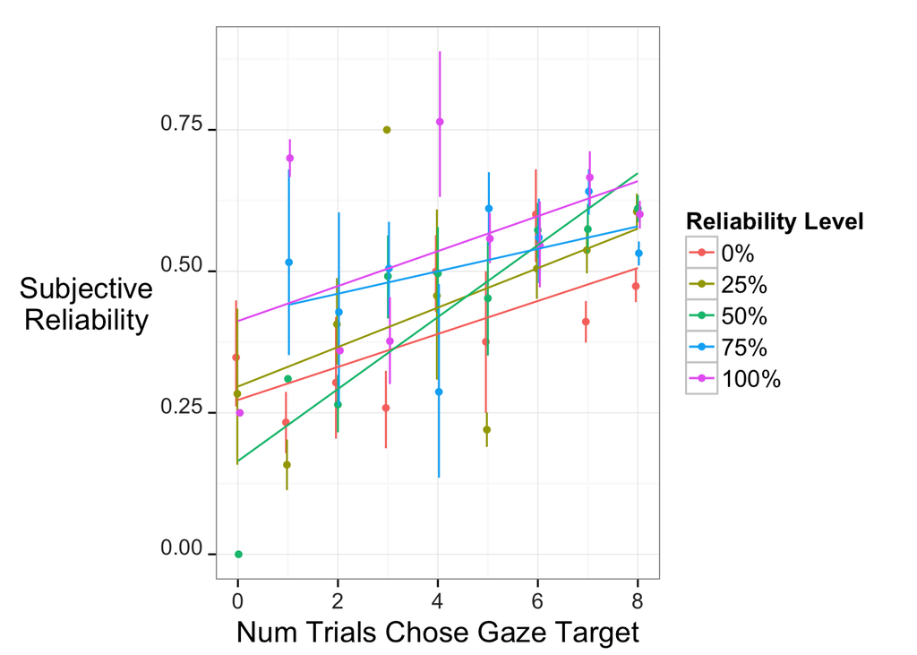

```r
expt3_subj_rel_plot <- qplot(total_exposure_correct, subj, col = prop_cond_clean,
      ymin = subj - cil, ymax = subj + cih,
      geom="pointrange",
      position=position_dodge(width=.1),
      data=ms_test_subj_rel, ylab="Subjective\nReliability",
      xlab="Num Trials Chose Gaze Target") +
    geom_smooth(method="lm", se=FALSE) +
    scale_color_discrete(name="Reliability Level") +
    theme(axis.title.x = element_text(colour="black",size=16,
                                      angle=0,hjust=0.5,vjust=0,face="plain"),
          axis.title.y = element_text(colour="black",size=16,
                                      angle=0,hjust=0.5,vjust=0.5,face="plain"),
          axis.text.x = element_text(colour="grey20",size=12,
                                     angle=0,hjust=0.5,vjust=0,face="plain"),
          axis.text.y = element_text(colour="grey20",size=12,
                                     angle=0,hjust=0.5,vjust=0,face="plain"),
          legend.text = element_text(size=13),
          legend.title = element_text(size=13, face="bold"))

expt3_subj_rel_plot
```

```r
# save output
ggsave("expt3-subj-rel-chose-gaze-target.pdf", expt3_subj_rel_plot, width=7, height=4)
```

### LMERs

Accuracy on exposure trials in test block

```r
m1_expo_expt3 <- glmer(correct ~ reliability +
                (1 | subids),
            data = df_expo_test_expt3, nAGQ = 0,
            family = binomial)
```

Accuracy on test trials in test block.

```r
# reliablity as factor, linear interaction
m1_expt3 <- glmer(correct ~ trialType * prop_cond_clean +
                (trialType | subids),
            data = df_test_test, nAGQ = 0,
            family = binomial)

m1.b_expt3 <- glmer(correct ~ trialType + prop_cond_clean +
                (trialType | subids),
            data = df_test_test,
            family = binomial)
```

Reliablity as continuous

```r
m2_expt3 <- glmer(correct ~ trialType * reliability +
                (trialType | subids),
            data = df_test_test,
            family = binomial)

m2.noslope_expt3 <- glmer(correct ~ trialType * reliability +
                (1 | subids),
            data = df_test_test,
            family = binomial)

# aggreate subject level then model
mss_expt3 <- df_test_test %>%
    group_by(subids, trialType, reliability) %>%
    summarize(correct = mean(correct))

# now model
m2.lm_expt3 <- lm(correct ~ trialType * reliability,
            data = mss_expt3)
```

#### Predict test performance from selecting target of gaze on exposure trials

```r
df_test_test <- df_test_test %>%
    group_by(subids) %>%
    mutate(total_exposure_correct = sum(correct_exposure))

# now model
m4_expt3 <- glmer(correct ~ total_exposure_correct * trialType +
                (trialType | subids),
             data = df_test_test,
            family = binomial)
```

Now we plot the new analysis: accuracy on test trials as a funciton of accuracy on exposure trials (selecting the gaze target).

Now plot

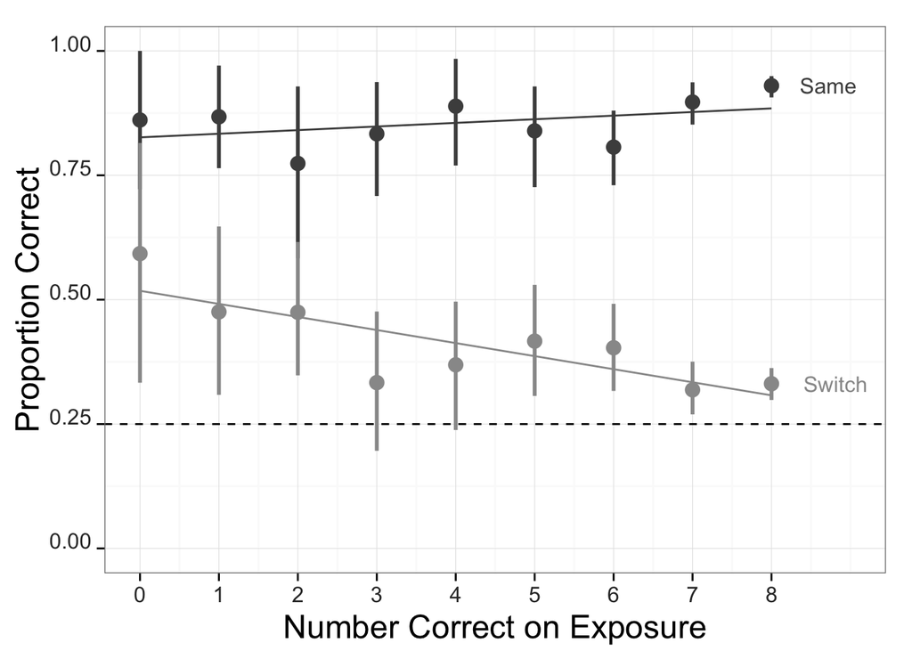

```r
expt3_acc_test_chose_gazetar <- ggplot(data=ms_acc_exp_test_expt3,
       aes(x=total_exposure_correct, y=correct, group=trialType,
           color=trialType, label = trialType)) +
    geom_pointrange(aes(ymin=correct - cil,
                        ymax=correct + cih),
                    width = .05, size=1) +
    geom_smooth(method='lm', se=F) +
    geom_hline(aes(yintercept=1/4), linetype = "dashed") +
    scale_x_continuous(limits=c(0,9), breaks=c(0:8)) +
    scale_y_continuous(limits=c(0,1)) +
    scale_colour_grey(start=0.3, end=0.6) +
    xlab("Number Correct on Exposure") +
    ylab("Proportion Correct") +
    labs(color = "Trial Type") +
    guides(color=FALSE) +
    geom_dl(method=list("last.qp",cex=1,hjust=-.5)) +
    theme(axis.title.x = element_text(colour="black",size=18,
                                      angle=0,hjust=0.5,vjust=0,face="plain"),
          axis.title.y = element_text(colour="black",size=18,
                                      angle=90,hjust=0.5,vjust=0.8,face="plain"),
          axis.text.x = element_text(colour="grey20",size=12,
                                     angle=0,hjust=0.5,vjust=0,face="plain"),
          axis.text.y = element_text(colour="grey20",size=12,
                                     angle=0,hjust=0.5,vjust=0,face="plain"),
          legend.text = element_text(size=13),
          legend.title = element_text(size=13, face="bold"))


expt3_acc_test_chose_gazetar
```

```r
ggsave("expt3-acc-test-chosegazetar.pdf", expt3_acc_test_chose_gazetar, width=7.5, height=5)
```